# BMI FTO Example PheWAS

## PheWAS R Package

This Rmd file will walk you through an example single SNP PheWAS. The data we will use today is simulated data, generated to reflect the real pattern of correlation found in the EHR. You have been provided one SNP, rs8050136, which is additively coded. There are three potential covariates included: age, is.male, and bmi. Remember that you can view documentation for the PheWAS package methods and other R functions using ?, e.g. ?phewas. In addition, the vignette contains a walkthrough and is available using vignette(“PheWAS-package”).

## Install PheWAS

We first need to install and load the v1.0 PheWAS package:

```r
if(!require(PheWAS)|packageVersion("PheWAS")<'0.99.4'){
  if(!require(devtools)){
    install.packages("devtools")
  }
  devtools::install_github("PheWAS/PheWAS")
  library(PheWAS)
}
if(!require(readr)) {
  install.packages("readr")
  library("readr")
} #For faster file loading
```

## Load data

There are a number of ways to load data, and we may have a variety of data sources for our analysis. First, we will load our genotype data from our plink raw file. It may be necessary to set or change your working directory (setwd). Alternatively, you can specify the complete path to the file you wish to load. Note that knitr requires us to use a special setup for the working directory above.

```r
#setwd("~/")
genotypes=read_delim("exome_chip_fto.raw",delim=" ") %>% transmute(id=FID,rs8050136_A)
```

We only need to keep the id and snp allele count columns. We can take a quick peek at our data to make sure it is coded properly and see our allele frequencies.

```r
table(genotypes$rs8050136_A)
```

```
##
##    0    1    2
## 3597 4797 1600
```

Next, we read our billing code data from a csv file. This file includes the id of the individual, the vocabulary and code for this row (ICD9CM or ICD10CM), and the count of days that code occurred. We specify the data types of the columns as R may want to read ICD9CM codes as numeric values (which can lose trailing and leading zeros).

```r
icd_codes=read_csv("icd_codes.csv", col_types="ifci")
```

Lastly, we will read our covariates in. These are saved in an RData file, which is a compressed, R specific file format.

```r
load("covariates.RData")
```

## Prepare Data

Using the raw format data from plink means our genotype data will be ready to go. We are not going to transform our covariates either, so that leaves us to set up our phenotypes. The below call will use the default minimum code count of 2. This may take a few minutes to complete. Note that we are restricting some phenotypes that are specific to males or females, eg prostate cancer. We could also define an aggregate function here, as we are using count data and not dates of occurrence (the preferred input), but it will be handled by the default.

```r
phenotypes=createPhenotypes(icd_codes,
                            id.sex = covariates %>% transmute(id, gender=ifelse(is.male,"M","F")))
```

```
## Mapping codes to phecodes...
```

```
## Aggregating codes...
```

```
## Mapping exclusions...
```

```
## Coalescing exclusions and min.code.count as applicable...
```

```
## Reshaping data...
```

We can actually export this data to a phenotype file that would work with plink if interested. These can be quite large, so we are restricting to a single phenotype here

```r
plinkPhewasExport(phenotypes %>% select(id, `250.2`),file="plink.pheno")
```

We can pass in these separate data frames we have now loaded directly into the phewas method, but we may want to investigate our data later, so we will merge it ourselves. Note that we need to specify the names of our id columns using the ‘by’ parameter.

```r
data=inner_join(inner_join(covariates, genotypes),phenotypes)
```

## Run PheWAS

```r
results=phewas(phenotypes=names(phenotypes)[-1], genotypes=c("rs8050136_A"), covariates=c("age", "is.male"), data=data, cores=4)
```

```
## Starting cluster...
```

```
## Cluster created, finding associations...
```

```
## Compiling results...
```

```
## Cleaning up...
```

## View Our Results

Checking out our results both as a table and figure can be helpful. There are many ways to order and view the results in R:

```r
head(addPhecodeInfo(results) %>% arrange(p))
```

```
##   phenotype         snp adjustment       beta         SE       OR
## 1       278 rs8050136_A       <NA>  0.2524423 0.04418914 1.287165
## 2     278.1 rs8050136_A       <NA>  0.2310162 0.04801243 1.259880
## 3     250.2 rs8050136_A       <NA>  0.1505459 0.03590362 1.162469
## 4       250 rs8050136_A       <NA>  0.1354938 0.03443024 1.145102
## 5       327 rs8050136_A       <NA>  0.1607309 0.04470669 1.174369
## 6       747 rs8050136_A       <NA> -0.2594095 0.07328165 0.771507
##              p     type n_total n_cases n_controls      HWE_p allele_freq
## 1 1.111527e-08 logistic    9766    1192       8574 0.01840773   0.3988327
## 2 1.497337e-06 logistic    9565     991       8574 0.13147757   0.3971772
## 3 2.752204e-05 logistic    9087    2168       6919 0.16940593   0.4015076
## 4 8.308798e-05 logistic    9339    2420       6919 0.24273993   0.4013278
## 5 3.241034e-04 logistic    9572    1177       8395 0.05137919   0.3990807
## 6 4.002833e-04 logistic    9812     440       9372 0.08310716   0.3998166
##   n_no_snp note                                     description
## 1        0      Overweight, obesity and other hyperalimentation
## 2        0                                              Obesity
## 3        0                                      Type 2 diabetes
## 4        0                                    Diabetes mellitus
## 5        0                                      Sleep disorders
## 6        0         Cardiac and circulatory congenital anomalies
##                  group
## 1  endocrine/metabolic
## 2  endocrine/metabolic
## 3  endocrine/metabolic
## 4  endocrine/metabolic
## 5         neurological
## 6 congenital anomalies
```

Head gives the top n rows (6 by default), addPhecodeInfo adds the name of the phewas code to the data frame, and arrange orders the data frame according to p-value. We can report all associations from the PheWAS with p<1e-6 using the code below. There’s also a handy method for creating an easy to use table in your knitted document! One can export the table with write.csv(), enabling it to be read by any spreadsheet software.

```r
phewasDT(results)
```

| phenotype | description | snp | OR | p | n_total | n_cases | n_controls |
| --- | --- | --- | --- | --- | --- | --- | --- |
| 278 | Overweight, obesity and other hyperalimentation | rs8050136_A | 1.29 | 1.11e-08 | 9766 | 1192 | 8574 |
| 278.1 | Obesity | rs8050136_A | 1.26 | 1.5e-06 | 9565 | 991 | 8574 |
| 250.2 | Type 2 diabetes | rs8050136_A | 1.16 | 2.75e-05 | 9087 | 2168 | 6919 |
| 250 | Diabetes mellitus | rs8050136_A | 1.15 | 8.31e-05 | 9339 | 2420 | 6919 |
| 327 | Sleep disorders | rs8050136_A | 1.17 | 0.000324 | 9572 | 1177 | 8395 |
| 747 | Cardiac and circulatory congenital anomalies | rs8050136_A | 0.77 | 0.0004 | 9812 | 440 | 9372 |
| 747.1 | Cardiac congenital anomalies | rs8050136_A | 0.77 | 0.0004 | 9812 | 440 | 9372 |
| 250.1 | Type 1 diabetes | rs8050136_A | 1.14 | 0.000471 | 8877 | 1958 | 6919 |
| 327.3 | Sleep apnea | rs8050136_A | 1.21 | 0.00261 | 8919 | 524 | 8395 |
| 352 | Disorders of other cranial nerves | rs8050136_A | 1.51 | 0.00464 | 8881 | 96 | 8785 |

[output cut: 417 more lines]

```r
write.csv(addPhecodeInfo(results) %>% arrange(p) %>% filter(p<1e-6) %>% select(phenotype, description, snp, OR, p, n_total, n_cases, n_controls), file="top-results.csv")
```

## Plot the Results

Creating a rough visualization is straight forward.

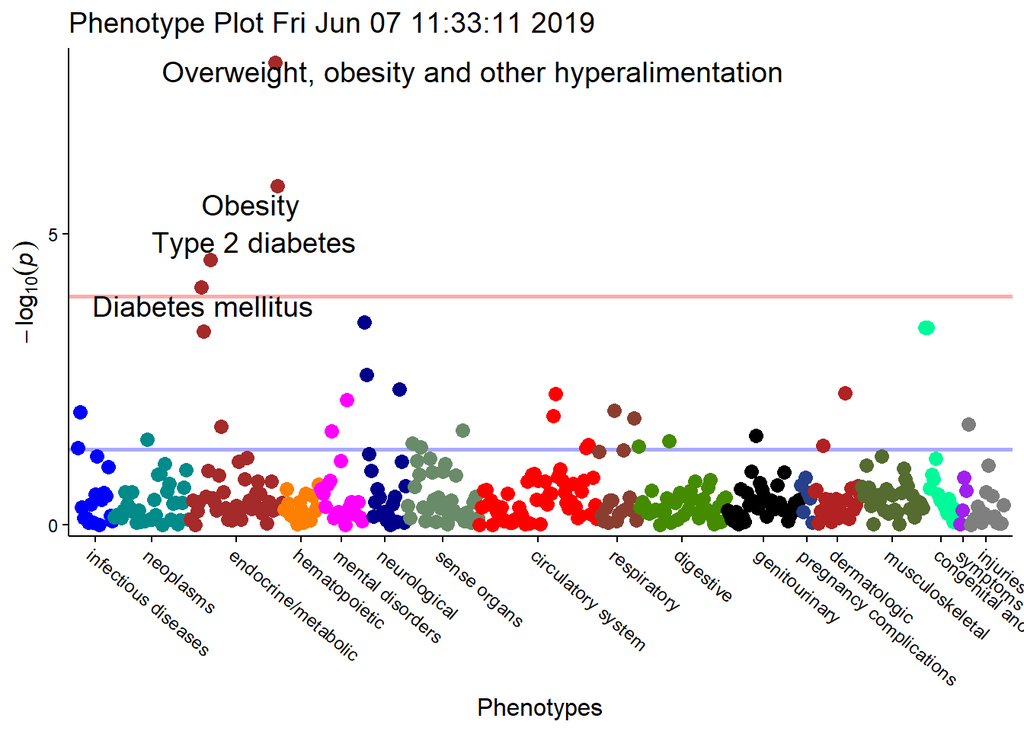

```r
phewasManhattan(results)
```

Try tweaking the plot using parameters, such as ‘title’. You can view other options using ?phenotypePlot, ?phenotypeManhattan, and ?phewasManhattan (they all direct to the same place). Remember that most parameters from phenotypePlot can be used in the “higher level” plotting functions as well.

```r
my_plot=phewasManhattan(results, title="My example plot", OR.direction=TRUE)
```

[output not shown]

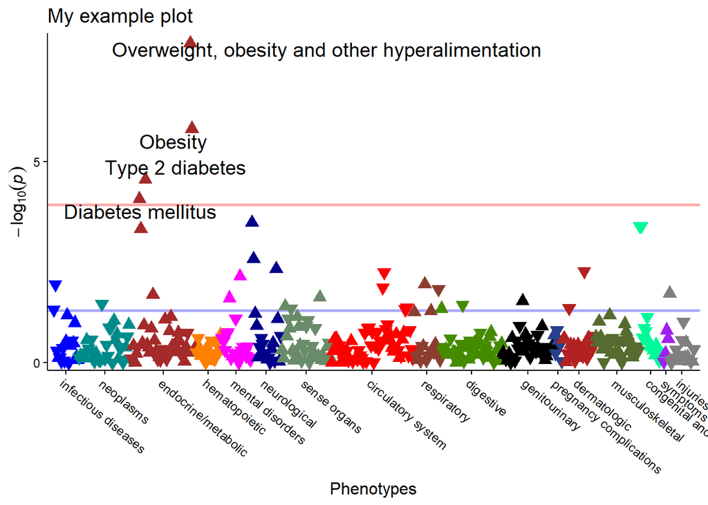

```r
my_plot
```

If you wish to plot directly to file, you can use png or pdf:

```r
png("MyPlot.png")
my_plot
dev.off()
```

Note that changing the size and scale of the output plot can affect how it looks. The method ggsave from ggplot2 can be helpful for getting consistent output.

## Adjusting for BMI (sometimes)

Let’s take a look at the effects of BMI on these associations. The phewas_ext function allows one run sets of associations with defined sets of covariates by providing a list of vectors instead of just one vector of covariates. Note that this will run the same analysis we did before, but now we will have a more complete result set.

```r
results=phewas_ext(phenotypes=names(phenotypes)[-1], genotypes=c("rs8050136_A"), covariates=list(c("age", "is.male"),c("age", "is.male","BMI")), data=data, cores=4)
```

```
## Starting cluster...
```

```
## Cluster created, finding associations...
```

```
## Compiling results...
```

```
## Cleaning up...
```

## Checking our BMI-adjusted results

If we want to see what the results look like for a single group of covariates, we will need to filter our results.

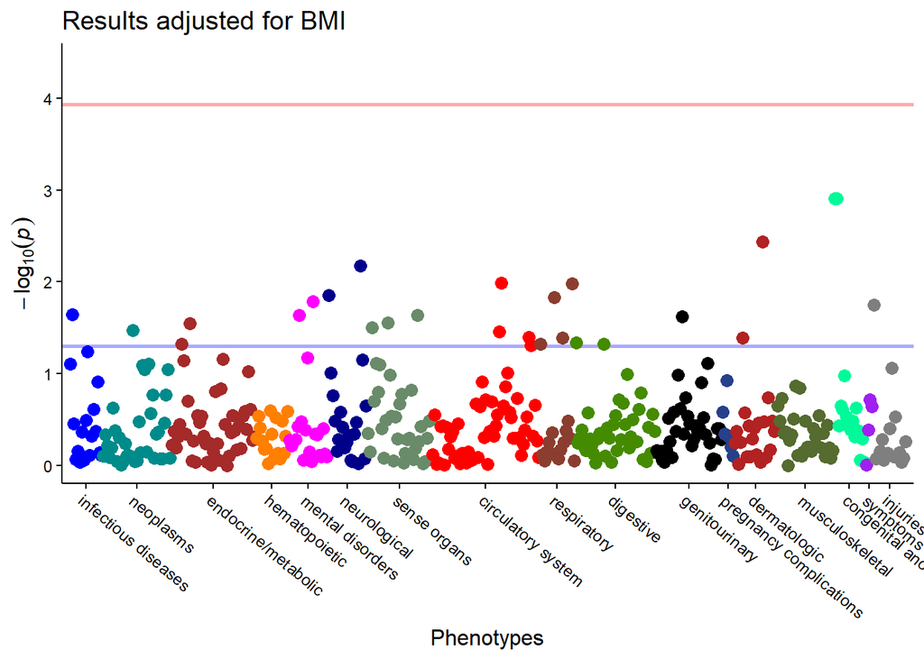

```r
results_bmi_adjusted = results %>% filter(covariates=='age,is.male,BMI')
phewasManhattan(results_bmi_adjusted, title="Results adjusted for BMI",y.axis.interval=1)
```

## Phenotypes predicting phenotypes

What happens if we predict phenotypes with our bmi variable?

```r
results_bmi=phewas(phenotypes=names(phenotypes)[-1], predictors = c("BMI"), covariates=c("age", "is.male"), data=data, cores=4, additive.genotypes = F)
```

```
## Starting cluster...
```

```
## Cluster created, finding associations...
```

```
## Compiling results...
```

```
## Cleaning up...
```

One will often see incredibly strong results in these cases, so don’t be surprised! In addition, here’s the raw code for creating a browsable data table- easily customized from the above default method phewasDT.

```r
DT::datatable(results_bmi %>% addPhecodeInfo() %>% arrange(p) %>% filter(!is.na(p)) %>% transmute(phenotype, description, predictor, OR=round(OR,2), p=signif(p,2), n_total, n_cases, n_controls))
```

|  | phenotype | description | predictor | OR | p | n_total | n_cases | n_controls |
| --- | --- | --- | --- | --- | --- | --- | --- | --- |
| 1 | 278 | Overweight, obesity and other hyperalimentation | BMI | 1.17 | 1.3e-158 | 9766 | 1192 | 8574 |
| 2 | 278.1 | Obesity | BMI | 1.17 | 2.5e-138 | 9565 | 991 | 8574 |
| 3 | 250.2 | Type 2 diabetes | BMI | 1.06 | 2.9e-44 | 9087 | 2168 | 6919 |
| 4 | 250 | Diabetes mellitus | BMI | 1.05 | 1.4e-42 | 9339 | 2420 | 6919 |
| 5 | 250.1 | Type 1 diabetes | BMI | 1.05 | 1.4e-32 | 8877 | 1958 | 6919 |
| 6 | 327.3 | Sleep apnea | BMI | 1.07 | 1.1e-21 | 8919 | 524 | 8395 |
| 7 | 250.7 | Diabetic retinopathy | BMI | 1.05 | 1.4e-20 | 7799 | 931 | 6868 |
| 8 | 743 | Osteoporosis, osteopenia and pathological fracture | BMI | 0.96 | 6e-19 | 9715 | 1709 | 8006 |
| 9 | 327 | Sleep disorders | BMI | 1.04 | 6.5e-16 | 9572 | 1177 | 8395 |
| 10 | 401 | Hypertension | BMI | 1.03 | 2.4e-14 | 9692 | 4629 | 5063 |

[output cut: 417 more lines]

## Conclusions

Congratulations, you have successfully run a PheWAS using R (and perhaps knitted your first markdown file)!